# IE360 Spring 2022

Homework 1

Refika Kalyoncu

# 1 Introduction

Since the increases in exchange rates increase the costs of the producers, they are also reflected in the sales prices, which causes inflation to rise. Inflation, on the other hand, is a situation that expresses a continuous and noticeable increase in the general level of prices. Another definition is the increase in nominal national income relative to the amount of goods purchased with this income. In this case, with the increase in the exchange rate, the purchasing power of people decreases. Based on this information, in this report, the relationship between the exchange rate increase and the housing price index was observed with the data obtained from [EVDS](https://evds2.tcmb.gov.tr/index.php?/evds/serieMarket).  
Generally, higher interest rates are a policy response to rising inflation. Because if there is inflation somewhere, when you lend money without interest, the purchasing power of money decreases in the time it takes to get this money back. Interest, on the other hand, prevents a decrease in the purchasing power of money. Therefore, the higher the inflation, the higher the interest rate. Considering the relationship between exchange rate and inflation, and the relationship between inflation and interest, it is thought that there is a positive relationship between exchange rate and interest rates, and this is also examined in the report.  
So many this report answers the question: **“Are there any relationships between exchange rate, housing price index and housing interest rate?”**

# 2 Analysis

```r
library(ggplot2)
library(dplyr)
library(tidyr)
library(readxl)
library(lubridate)
library(zoo)
library(corrplot)
library(hrbrthemes)
library(viridis)
library(ggridges)

setwd("C:/Users/HP/Desktop/IE360_HW1/HW2")

data<-read_excel("mydata.xlsx")

data<-data%>%rename(Date=Date,
                      ExchangeRate_EUR=`Euro(Buying)`,
                      Housing.InterestRate=`Housing(Interest Rate)`,
                      Housing.PriceIndex=`RPPI`,
                      Apartment.for.sale=`Satılık Daire`)%>%
  mutate(Date=as.Date(as.yearmon(Date)))
```

## 2.1 Visualization of Time Series

Monthly time series data are given below:

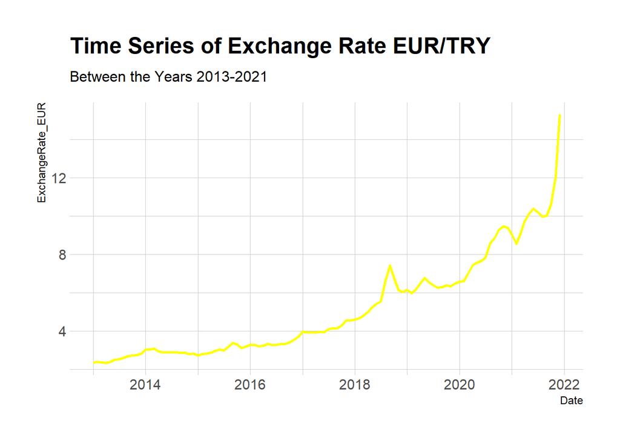

```r
ggplot(data,aes(x=Date))+
  geom_line(size=1,color="yellow",aes(y=ExchangeRate_EUR))+
  theme_ipsum()+
  ggtitle("Time Series of Exchange Rate EUR/TRY",
          subtitle="Between the Years 2013-2021")
```

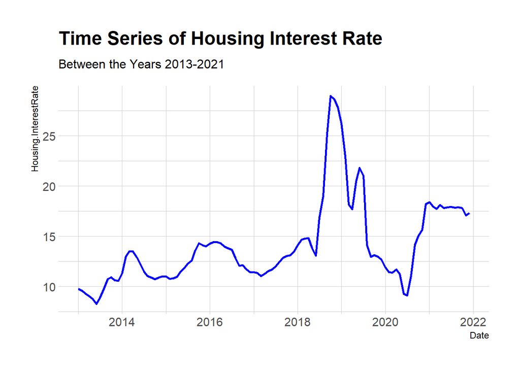

```r
ggplot(data,aes(x=Date))+
  geom_line(size=1,color="blue",aes(y=Housing.InterestRate))+
  theme_ipsum()+
  ggtitle("Time Series of Housing Interest Rate",
          subtitle="Between the Years 2013-2021")
```

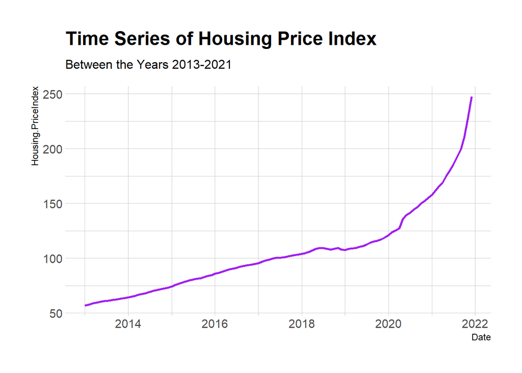

```r
ggplot(data,aes(x=Date))+
  geom_line(size=1,color="purple",aes(y=Housing.PriceIndex))+
  theme_ipsum()+
  ggtitle("Time Series of Housing Price Index",
          subtitle="Between the Years 2013-2021")
```

The monthly plots of Exchange Rate , Housing Interest rate and Housing Price index can be seen in above. We can observe that exchange rate and price index are increasing exponentially and neither of the 3 data shows a property of an obvious seasonality.  
When we look through the plots directly a relationship between housing price index and exchange rate can be clearly seen. So they should be highly correlated which will be evaluated numerically in below sections.  
Compared to exchange rate and price index, there are big fluctuations in interest rate.  
Until late 2018 the interest rate increases with significant fluctuations. In late 2018 interest rates has a big increase due central bank policies. Then in 2019 it decreases sharply and also during the pandemic the interest rate decreased as well to diminish the effects of pandemic.

## 2.2 Visualization of Time Series on a Single Plot

To compare values on a single plot we are going to normalize the values of our data. To do this we are going to subtract min of each data from the actual value and divide it to max-min value of the data. So that each value will be between zero and 1.

```r
min1<-min(data$ExchangeRate_EUR)
max1<-max(data$ExchangeRate_EUR)
min2<-min(data$Housing.InterestRate)
max2<-max(data$Housing.InterestRate)
min4<-min(data$Housing.PriceIndex)
max4<-max(data$Housing.PriceIndex)

data<-data%>%mutate(N_ExchangeRate_EUR=(ExchangeRate_EUR-min1)/(max1-min1),
              N_Housing.InterestRate=(Housing.InterestRate-min2)/(max2-min2),
              N_Housing.PriceIndex=(Housing.PriceIndex-min4)/(max4-min4))
```

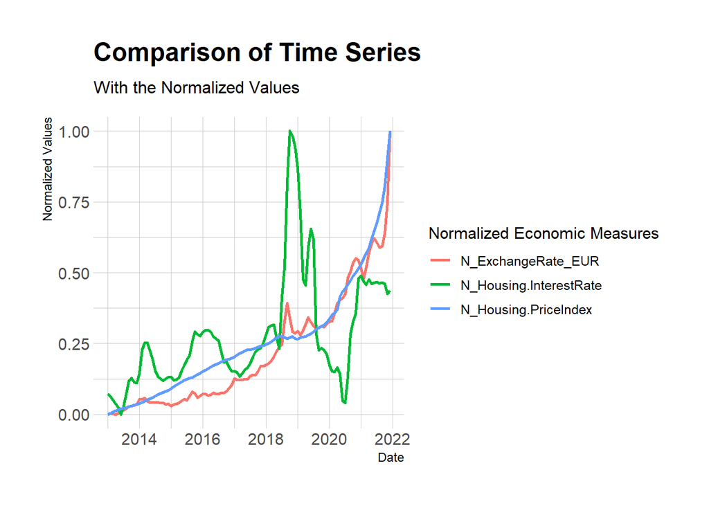

```r
data%>%pivot_longer(.,cols=c(N_ExchangeRate_EUR,N_Housing.InterestRate,N_Housing.PriceIndex),
                    names_to="name",
                    values_to="values")%>%
  ggplot(.,aes(x=Date,y=values,color=name,shape=name))+
  geom_line(size=1)+
  labs(color="Normalized Economic Measures",
       y="Normalized Values")+
  scale_colour_discrete()+
  theme_ipsum()+
  ggtitle("Comparison of Time Series",
          subtitle="With the Normalized Values")
```

As one can see price index and exchange rate increases almost smoothly compared to Interest rate. The interest rate is being determined according to the change in economy and also changes in economic policies. These changes are not applied instantly according to the other variables and also the appliance once increment and reduction depends on the different policies for each different period which maybe the reason of the enormous fluctuations.

## 2.3 Visualization of Histograms

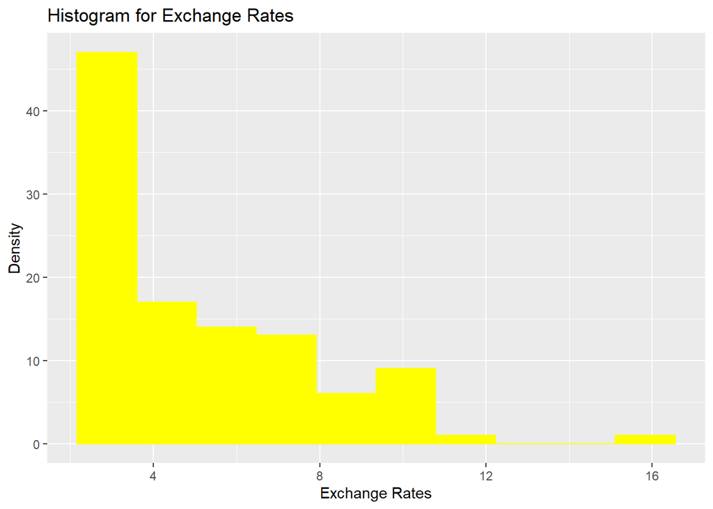

```r
ggplot(data, aes(ExchangeRate_EUR))+geom_histogram(bins=10,color="yellow",fill="yellow")+ggtitle("Histogram for Exchange Rates") + xlab("Exchange Rates") + ylab("Density")
```

The exchange rate increases almost exponentially according to the first plot of exchange rate.If we look through the histogram almost half of the data is gathered between the interval of 0-4 and other intervals consist of comparably small portions of data. Which shows that the data was stable between 0-4 for sometime then it started to increase sharply.

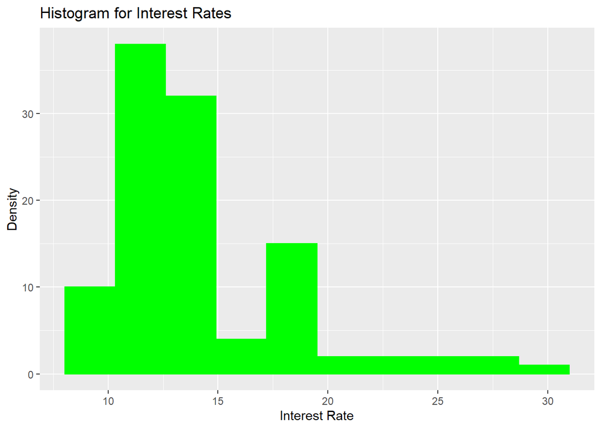

```r
ggplot(data, aes(Housing.InterestRate))+geom_histogram(bins=10,color="green",fill="green")+ggtitle("Histogram for Interest Rates") + xlab("Interest Rate") + ylab("Density")
```

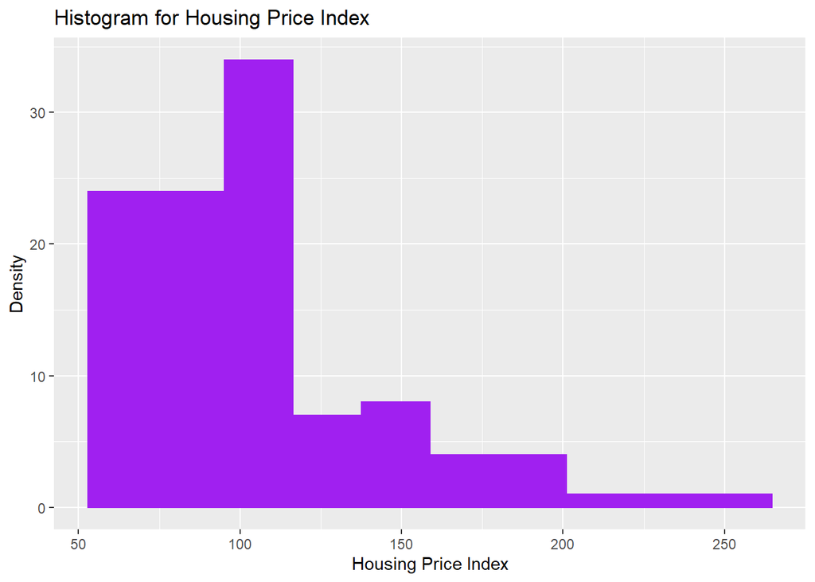

```r
ggplot(data, aes(Housing.PriceIndex))+geom_histogram(bins=10,color="purple",fill="purple")+ggtitle("Histogram for Housing Price Index") + xlab("Housing Price Index") + ylab("Density")
```

According to the histogram of Price Index it seems that there is an accumulation between 0 and 100.As we can also observe from the plot there is a sharp increase after the value of 100 after late 2018.

## 2.4 Visualization of Monthly Histograms

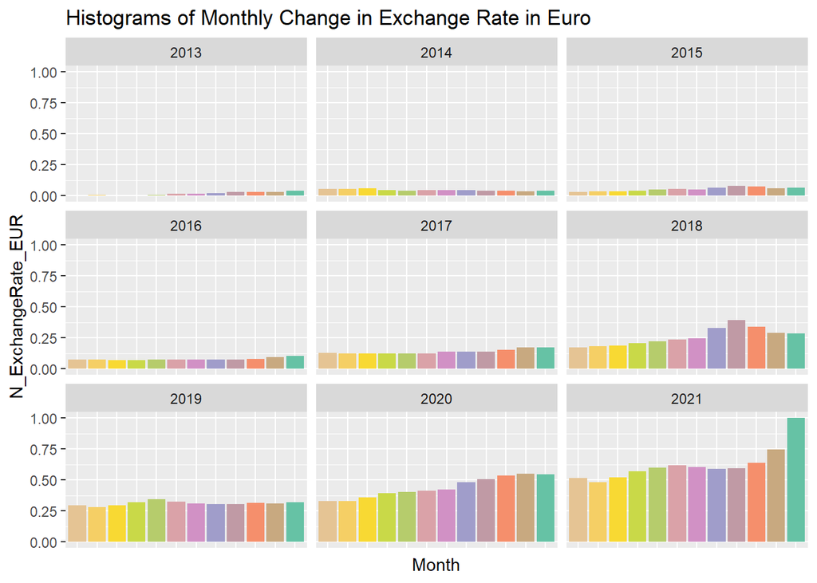

```r
ggplot(data,aes(x=factor(month(Date)),y=N_ExchangeRate_EUR))+geom_bar(stat="identity",aes(fill=month(Date)))+facet_wrap(~year(Date))+
  theme(legend.position = "none",
        axis.ticks.x = element_blank(),
        axis.text.x = element_blank())+
  labs(x="Month",title="Histograms of Monthly Change in Exchange Rate in Euro ")+scale_fill_distiller(palette="Set2")
```

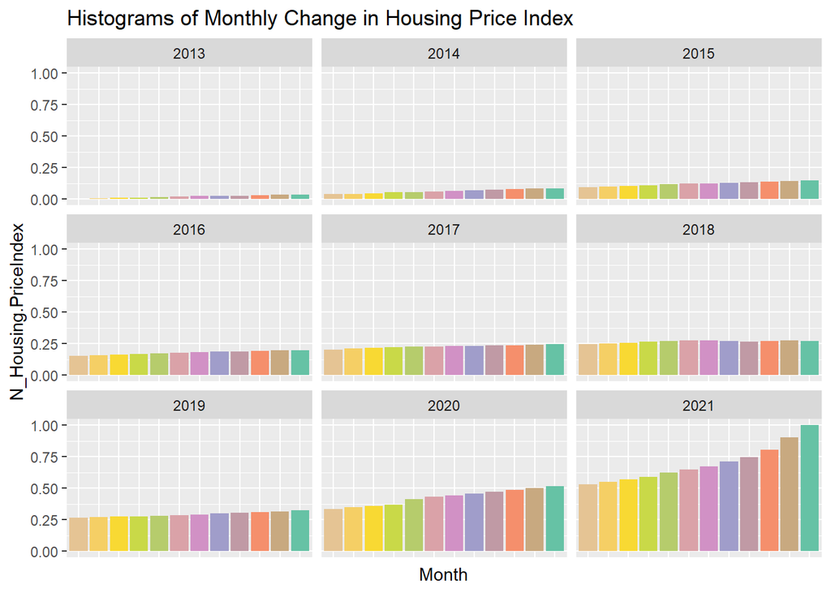

```r
ggplot(data,aes(x=factor(month(Date)),y=N_Housing.PriceIndex))+geom_bar(stat="identity",aes(fill=month(Date)))+facet_wrap(~year(Date))+
  theme(legend.position = "none",
        axis.ticks.x = element_blank(),
        axis.text.x = element_blank())+
  labs(x="Month",title="Histograms of Monthly Change in Housing Price Index ")+scale_fill_distiller(palette="Set2")
```

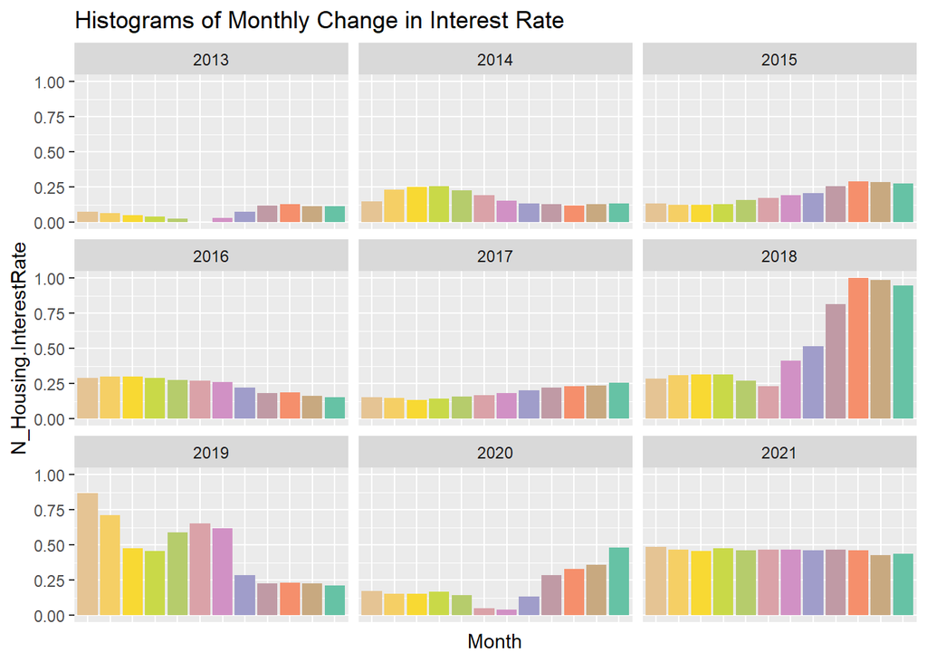

```r
ggplot(data,aes(x=factor(month(Date)),y=N_Housing.InterestRate))+geom_bar(stat="identity",aes(fill=month(Date)))+facet_wrap(~year(Date))+
  theme(legend.position = "none",
        axis.ticks.x = element_blank(),
        axis.text.x = element_blank())+
  labs(x="Month",title="Histograms of Monthly Change in Interest Rate ")+scale_fill_distiller(palette="Set2")
```

When the normalized values of the data considered we can easily see the almost constant increase in price index again in these histograms.  
Also even though it is not smooth as price index exchange rate also follows an increasing trend.  
The Housing Interest Rate data doesn’t exactly follows a trend however it is tend to increase until 2018 and decreases with the policies in 2019 and covid as also observed in the first plot. It seems to follow a more stable trend in recent year.  
According to an article in [cumhuriyet.com](https://www.cumhuriyet.com.tr/) the main reason for the increase in interest rate in late 2018 was the rapid depreciation in the external and internal value of TL and the increasing trend in future risks.

## 2.5 Visualization of Pairwise Correlations

To understand the relationships between the data we can look for the correlation value.

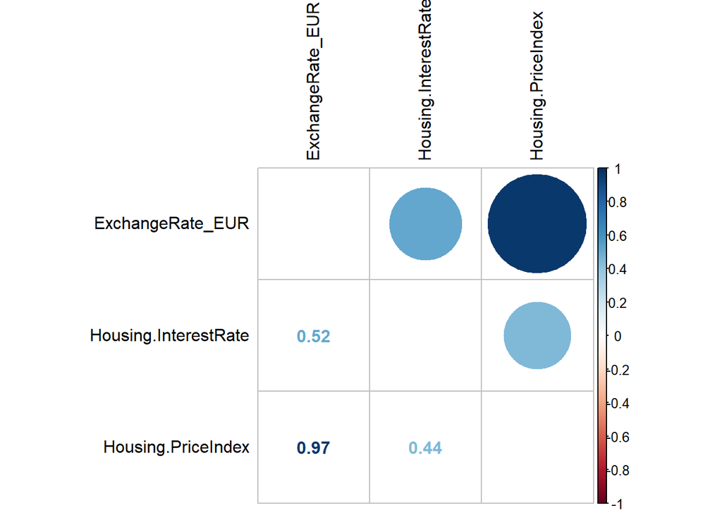

```r
cor_numVar <- cor(data[,c(2,3,5)], use="pairwise.complete.obs")

corrplot.mixed(cor_numVar, tl.col="black", tl.pos = "lt")
```

The correlation value shows that housing price index and the exchange rate is highly correlated. The perfectly correlated value is 1 and our value is 0.97 which shows almost the perfect correlation.There is a tight link between exchange rate and inflation in developing countries such as Turkey. With an increase in the exchange rate, prices increase as inflation increases. That’s why the house price index has also increased. So, that explains the high correlation between these 2 data.  
The correlation value between interest rate and exchange rate is also positive and above 0.5. Which proves that there exist a positive relation between exchange and interest rate which may be due to as exchange rate increases the inflation rate increases so the interest rate.

## 2.6 Visualization of Monthly Pairwise Correlations

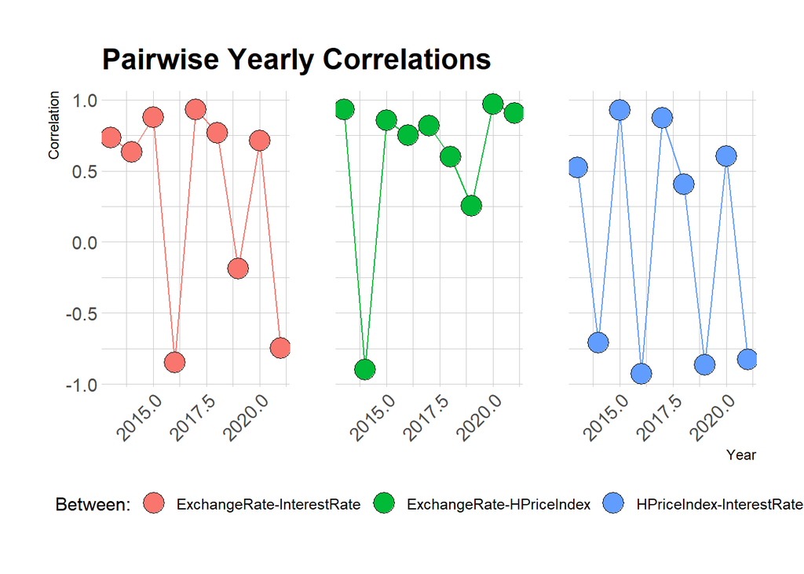

```r
d<-data%>%group_by(year(Date))%>%
  mutate(ExchangeRateEUR_HousingInterestRate=cor(N_ExchangeRate_EUR,N_Housing.InterestRate),
         ExchangeRateEUR_HousingPriceIndex=cor(N_ExchangeRate_EUR,N_Housing.PriceIndex),
         HousingPriceIndex_HousingInterestRate=cor(N_Housing.InterestRate,N_Housing.PriceIndex))


d%>%
  pivot_longer(.,cols=c(ExchangeRateEUR_HousingInterestRate,ExchangeRateEUR_HousingPriceIndex,HousingPriceIndex_HousingInterestRate))%>%
  ggplot(., aes(x=year(Date), y=value)) +
  geom_line( aes(color=name)) +
  geom_point(aes( fill=name),shape=21, color="black", size=6) +
  theme_ipsum()+
  labs(fill="Between:",color="Between:",
       y="Correlation",
       x="Year")+
  facet_wrap(~name)+
  ggtitle("Pairwise Yearly Correlations")+
  theme(legend.position = "bottom",
        axis.text.x = element_text(angle = 45, hjust = 1),
        strip.text.x = element_blank())+
  scale_fill_discrete(labels=c("ExchangeRate-InterestRate","ExchangeRate-HPriceIndex","HPriceIndex-InterestRate"))+
  scale_color_discrete(labels=c("ExchangeRate-InterestRate","ExchangeRate-HPriceIndex","HPriceIndex-InterestRate"))
```

# 3 Google Trend

I searched for “Satılık daire” in Google trend to see what is the relation between searching for houses and price indexes.  
My question was **“Are there any relationship between searches of”Home for sale” on Google and Housing Price index, exchange rate or Housing Interest Rate ?**

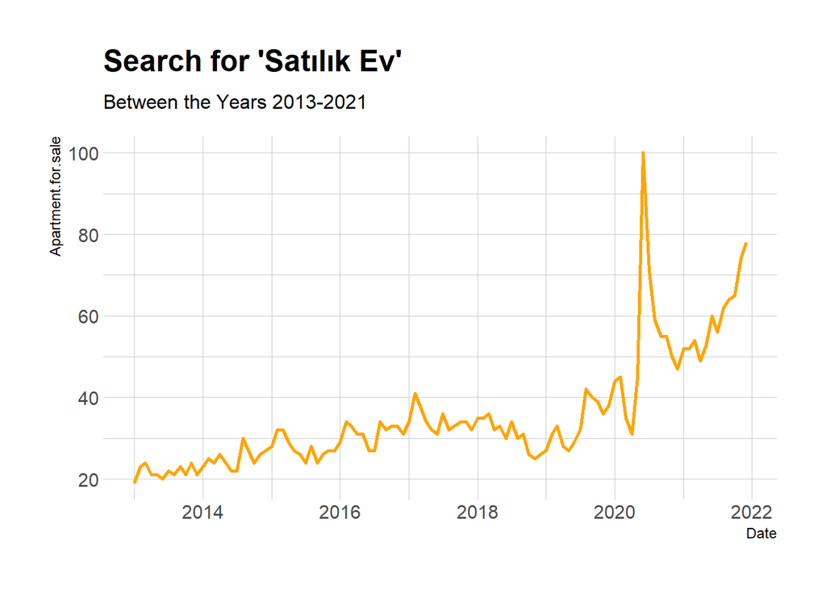

```r
ggplot(data,aes(x=Date))+
  geom_line(size=1,color="orange",aes(y=Apartment.for.sale))+
  theme_ipsum()+
  ggtitle("Search for 'Satılık Ev'",
          subtitle="Between the Years 2013-2021")
```

The rise in the data of houses for sale in the middle of 2020 may be due to the fact that everyone returns to online life with the emergence of covid and therefore changes location. Apart from this, it is observed that the data tends to increase in general.

Before examining the data I thought that as house prices increased, people would search less for homes for sale.However the correlation between price index and the Google trend data shows exactly the opposite. The correlation value between housing price index and “home for sale” search is 0.86. Which shows the data is highly correlated in a positive manner. So,it seems that as the price increases people tend to search more for apartments for sale. This could be as a result of not being able to find an affordable house, people search for a house for much longer time.Therefore the amount of searching for the “Satılık daire” may be increasing.Since the exchange rate and housing interest rate is positively correlated with price index ,it is not surprising that “home for sale” search has also positive correlation with others as well.One can see the correlation values below:

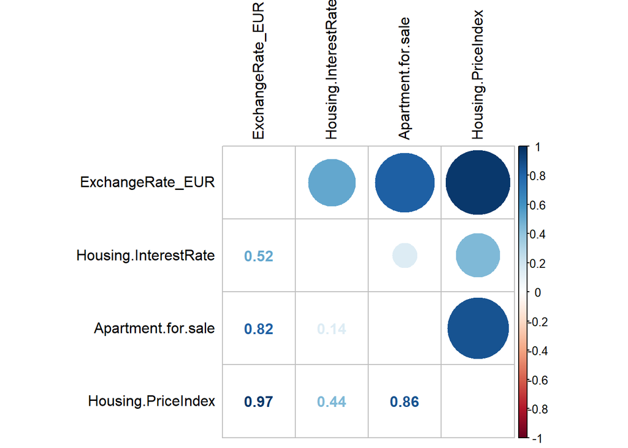

```r
cor_numVar <- cor(data[,c(2,3,4,5)], use="pairwise.complete.obs")

corrplot.mixed(cor_numVar, tl.col="black", tl.pos = "lt")
```